# R Notebook

# decline and fall of pokemon empire

昔は人気なかったやつが人気でたり、逆だったり、の極端なやつらをいくつか経時的に追ってったほうがいい気がしてきた。 そういうやつを見つけてみよう：

relativeなrankをつくって、その変動が大きいものをみつけるか。ずっとRankが低い・高いやつをハイライトするのもよさそう

1. 一番大きなrankから一番小さなRankにいっている（栄枯盛衰のうち栄転）
2. 一番小さなrankから一番大きなRankにいっている（栄枯盛衰のうち転落）
3. 大→小→大 （一時期すごかった、はやり）
4. 小→大→小 （カムバック）
5. ずっとちいさなRank（ずっと栄光）
6. ずっと大きなRank（不人気） くらいがとれると面白そう どうやるの relative_rankが…
11. na.omitしたrankが平均して一番小さい 1.na.omitしたrankが平均して一番大きい…？

## no show

COUNT ABSENT

でてくるポケモンではなく、でてこないポケモンに着目してみる。 でてこないポケモンの数もシミュレーションと違う。 prepare all possible entries of pokemons, in that specific era. for example, pokedex 152, gen 2 pokemon cannot appear in series_gen_era == 1 period.

```r
# empty_rank_df <-
#   tibble(
#     pokedex_id = map(
#       .x = 1:8,
#       ~ 1:df_game_gen$pokemon_cumulative_n[.x]
#     ) |>
#       unlist(),
#     series_gen_era = map(
#       .x = 1:8,
#       ~ rep(.x, df_game_gen$pokemon_cumulative_n[.x])
#     ) |>
#       unlist()
#   ) |>
#   left_join(df_names, by = "pokedex_id")
```

`df_no_appearance_emp`は名前つき。どの名前/pokedex_idのやつが欠けているのかがわかる。

[figure not shown]

12はともかく、Era 8についても０になっちゃったんですが…なんで？ほんとう？

| n | ecdf | run | series_gen_era | pokedex_id | condition | card_name | card_type | pokemon_name | pokemon_name_ja | pokemon_gen | pokemon_name_simplified | image_large | image_small |
| --- | --- | --- | --- | --- | --- | --- | --- | --- | --- | --- | --- | --- | --- |

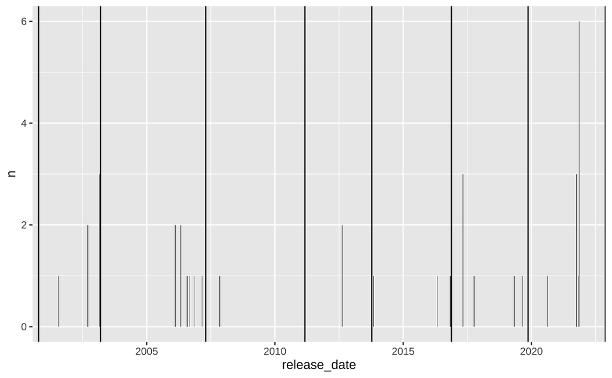

```r
df_gene |>
  filter(pokemon_name == "Mew") |>
  count(release_date) |>
  ggplot(aes(x = release_date, n)) +
  geom_col() +
  geom_vline(
    data = df_game_gen,
    aes(xintercept = game_release_date),
    inherit.aes = FALSE
  )
```

たしかにぽっかりあいてますね…。 kadabraニキは？そんなに人気ないの？

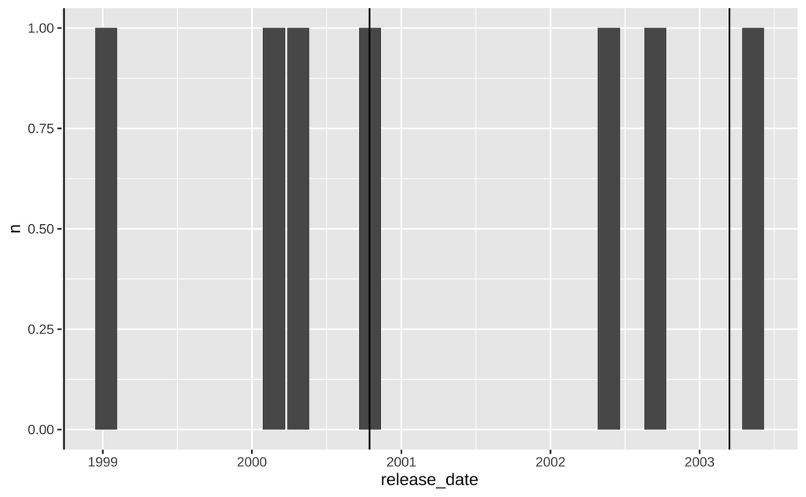

```r
df_gene |>
  filter(pokemon_name == "Kadabra") |>
  count(release_date) |>
  ggplot(aes(x = release_date, n)) +
  geom_col() +
  geom_vline(
    data = df_game_gen,
    aes(xintercept = game_release_date),
    inherit.aes = FALSE
  )
```

series_gen_era == 8ともなると非常にポケモンが多いので一度も登場していないカードも相当ありそう。

これもかなりランダムとは違う気がするし、測れる気がする。

## compare voids with random

↓とりあえずシミュレーションで一度も登場しなかったポケモンの名前をrun==1に限定してプロットしてみる。

[figure not shown]

↑当然といえば当然なんだけどまんべんなく登場しないポケモンがでてくる。さっきのEmpデータとは大違いである。

### compare numerically, then visually

Game-gen-eraごとに集計して、その数がどれくらいシミュレーションと違うかみてみよう ただしrunすべてについて行うので、right_joinが全部に起きないといけないので難しそう まずはシミュレーションについて。

`df_no_appearance_emp2`は`df_no_appearance_emp`をもとにしているが、名前の情報をなくしている。とにかくどの世代のポケモンがそれぞれの時期に何人登場していないかがわかる。すべてのありうる組み合わせについて集計したいので、completeと直後のfilterでなんとかした。もっと集計すれば、それぞれの時期に（世代関係なく）何人登場していないかデータになるだろうけど、一旦ここで止めている。

いくら第３世代登場直後でも確率的には、ランダムにとれば少しは登場しない奴らがいてもおかしくないのに、全然「一回も登場しないようなポケモンがいない」ということで、正の新奇バイアス…というか、Positive Debutant Biasの傍証といえましょう。第５世代がでるころともなるとその御利益もなくなり、かなりの数が未登場。 ちょっとポケモンじたいの世代は忘れて、時期ごとのAbsenteeの数だけでみてみましょう：

```r
# summarise by pokemon_gen & series_gen_era
df_no_appearance_summary <- bind_rows(
  df_no_appearance_emp2, df_no_appearance_sim
  ) |>
  group_by(series_gen_era, pokemon_gen, condition) |>
  summarise(mean_count_no_shows = mean(count_no_shows))
# note that `mean_count_no_shows` is
# exactly the same as the count_no_shows.
# using the same name just for plotting purposes.

# summarise by series_gen_era only
df_no_appearance2 <- bind_rows(
  df_no_appearance_emp2, df_no_appearance_sim
  ) |>
  group_by(series_gen_era, condition, run) |>
  summarise(sum = sum(count_no_shows)) |>
  ungroup() |>
  complete(series_gen_era, condition, fill = list(sum = 0))
```

### plot

```r
p_pandoras_aggregate <-
df_no_appearance2 |>
  filter(condition == "simulations") |>
  ggplot(aes(x = series_gen_era, y = sum, fill = series_gen_era)) +
  geom_quasirandom(
    size = .1,
    pch = 21,
    colour = "transparent",
    stroke = 0
  ) +
  geom_line(
    data = df_no_appearance2 |> filter(condition == "pokemon name"),
    colour = pokemon_blue,
    size = .2,
    linetype = "dotted"
  ) +
  geom_point(
    data = df_no_appearance2 |> filter(condition == "pokemon name"),
    fill = pokemon_blue,
    pch = 21,
    colour = "black",
    stroke = .1
  ) +
  scale_fill_viridis_c() +
  theme_pokemon
ggsave("./output/p_pandoras_aggregate.png", width = 100, height = 100, units = "mm", dpi = 600)
```

### plot simVSemp, zansa

紀要載せたいなー [rbind trick](https://stackoverflow.com/questions/25961897/how-to-merge-2-vectors-alternating-indexes)

```r
p_no_appearance <-
  df_no_appearance_summary |>
  ggplot(aes(x = series_gen_era, y = mean_count_no_shows, colour = condition)) +
  geom_violin(
    data = df_no_appearance_sim,
    aes(group = series_gen_era, y = count_no_shows),
    scale = "count",
    fill = pokemon_yellow |> lighten(0.6),
    colour = "transparent",
    bw = .5,
    trim = FALSE
  ) +
  geom_line(
    size = .5
  ) +
  geom_point(
    size = .5,
    # stroke = .05
  ) +
  scale_colour_manual(
    values = c("pokemon name" = pokemon_blue, "simulations" = pokemon_yellow)
  ) +
  scale_x_continuous(
    breaks = 1:8,
    labels = rbind("", 1:4 * 2) |> c()
  ) +
  # scale_y_continuous(trans = "log10")
  facet_wrap(
     vars(pokemon_gen),
     nrow = 1,
     scales = "free",
     labeller = pokemon_gen_labeller
  ) +
  theme_pokemon +
  theme(
    # aspect.ratio = 1,
    # legend.position = "none"
  )
ggsave("./output/p_count_absent.png", width = 166, height = 166/4, unit = "mm", dpi = 600)
ggsave("./output/p_count_absent.pdf", width = 166, height = 166/4, unit = "mm", dpi = 600)
```

## 残差

```r
df_no_appearance_residual <- full_join(
  df_no_appearance_emp2 |> select(-condition), df_no_appearance_sim |> select(-condition), by = c("series_gen_era", "pokemon_gen")
  ) |>
  mutate(count_no_shows.x = replace_na(count_no_shows.x, 0)) |>
  rename(empirical = "count_no_shows.x", simulations = "count_no_shows.y") |>
  mutate(residual = empirical - simulations)

df_no_appearance_residual |>
  # filter(condition == "simulations") |>
  ggplot(aes(x = series_gen_era, y = residual, colour = pokemon_gen - series_gen_era)) +
  geom_hline(yintercept = 1, colour = "blue", alpha = .4) +
  geom_jitter(size = .3, alpha = .3) +
  scale_colour_viridis_c() +
  theme_pokemon
```

[output not shown]

これはプロットが難しいな…ggridgesするときがきた？

```r
p_pandoras_ridges <-
df_no_appearance_residual |>
  # mutate(series_gen_era = )) |>
  ggplot(aes(
    y =fct_rev(as.factor(series_gen_era)),
    # y = paste0("Gen", series_gen_era,"Era, Gen", pokemon_gen, "pokemons"),
    x = residual,
    fill = (pokemon_gen - series_gen_era) |> as.factor()
    # group = pokemon_gen
  )) +
  geom_vline(xintercept = 0) +
  geom_density_ridges(
    rel_min_height = .01,
    bandwidth = .8,
    alpha = .8,
    size = .2
    ) +
  scale_y_discrete(
    "Era",
    labels =  8:1 |> as.roman()
  ) +
  scale_fill_viridis_d("Gens Past Release", option = "B") +
  theme_pokemon +
  theme(legend.position = c(0.2, 0.8))
```